# 자연언어처리 11주차_딥러닝을 사용한 자연언어처리 #1: 텍스트 임베딩, 딥러닝용 전처리, Keras 실습

고려대학교 일반대학원 심리학과

2025년 11월 10일 월요일 4-5교시

**[표 1] 11주차 수업에 사용된 주요 함수 목록**

| 함수 | 출처 패키지 | 역할 | 주요 논항 및 예시 |
| --- | --- | --- | --- |
| fromJSON() | jsonlite | JSON 파일을 R 리스트/데이터프레임으로 로드 | fromJSON(“shopping1_0601.json”) |
| map_dfr() / map_chr() | tidyverse(purrr) | 리스트의 각 요소(파일)에 함수를 적용하고 결과를 (DF/벡터로) 반환 | map_dfr(file_paths, load_shopping_data) |
| py_install() | reticulate | Reticulate용 Python 가상환경에 라이브러리 설치([EX], gensim==3.8.3) | py_install(“gensim==3.8.3”, pip = TRUE) |
| import() | reticulate | R에서 Python 라이브러리(gensim, kiwipiepy)를 객체로 불러오기 | gensim <- import(“gensim”) |
| py_to_r() | reticulate | Python 객체를 R 객체로 변환 | py_to_r(`w2v_model_ft$wv$index2word`) |
| ncol() | Base R | 행렬(vectors)의 열(column) 개수를 반환 | embedding_dim_w2v <- ncol(w2v_model$wv$vectors) |
| as.character() | Base R | Python 객체(dict_keys)를 R의 문자열 벡터로 강제 변환 | w2v_vocab_list <- as.character(`names(w2v_model$wv$vocab)`) |
| as.numeric() | Base R | Python 객체(numpy)를 R의 숫자 벡터로 강제 변환 | embedding_vector <- as.numeric(`w2v_model$wv[[word]]`) |
| text_tokenizer() | keras | 빈 단어 사전(Vocabulary) 객체를 생성(Keras 전처리 1단계) | tokenizer <- text_tokenizer(num_words = 5000, oov_token = “<OOV>”) |
| fit_text_tokenizer() | keras | 빈 사전에 텍스트 데이터를 읽혀 단어 인덱스를 완성(Keras 전처리 2단계) | fit_text_tokenizer(tokenizer, `all_data$tokens`) |
| texts_to_sequences() | keras | 텍스트 문자열을 정수 인덱스 시퀀스로 변환(Keras 전처리 3단계) | sequences <- texts_to_sequences(tokenizer, `all_data$tokens`) |
| pad_sequences() | keras | 정수 시퀀스의 길이를 maxlen으로 통일 (0 패딩 추가)(Keras 전처리 4단계) | pad_sequences(sequences, maxlen = 100, padding = “pre”) |
| to_categorical() | keras | 정수 라벨(0,1,2..)을 ‘원-핫 인코딩’ 벡터([0, 0, 1, …])로 변환 | to_categorical(`all_data$label_numeric`, num_classes = 5) |
| keras_model_sequential() | keras | 딥러닝 레이어를 순차적으로 쌓는 ‘바닥판’ 모델을 생성 | model <- keras_model_sequential() %>% … |
| layer_embedding() | keras | 정수 인덱스를 ‘의미 벡터’로 변환하는 ’조회 테이블’ 레이어 | layer_embedding(input_dim = 5000, output_dim = 200, input_length = 100) |
| layer_global_average_pooling_1d() | keras | 단어 벡터들(3D)을 ‘평균’내어 하나의 ’문장 벡터’(2D)로 압축 | layer_global_average_pooling_1d() |
| layer_dense() | keras | 입력 벡터에 (w * x + b) 계산을 수행하는 ‘두뇌’ 레이어 | layer_dense(units = 5, activation = “softmax”) |
| layer_dropout() | keras | 학습 시 뉴런 일부를 꺼서 과적합을 방지하는 레이어 | layer_dropout(rate = 0.3) |
| set_weights() | keras | 레이어의 가중치(w)를 사전학습 행렬(embedding_matrix)로 설정 | get_layer(model, index = 1) %>% set_weights(list(embedding_matrix)) |
| compile() | keras | 모델의 ‘학습계획’ 설정(옵티마이저, 손실함수, 평가지표) | compile(optimizer = “adam”, loss = “categorical_crossentropy”, metrics = “accuracy”) |
| fit() | keras | 데이터(x_train, y_train)로 모델의 ’w’와 ’b’를 학습(업데이트) | fit(x_train, y_train, epochs = 10, batch_size = 32, validation_split = 0.2) |
| evaluate() | keras | 학습된 모델을 테스트 데이터(x_test)로 최종 평가 | evaluate(x_test, y_test, verbose = 0) |
| keras_model() | keras | 여러 레이어를 자유롭게 연결하는 함수형 API 모델 생성(특징 추출용) | extractor_model <- keras_model(inputs = `model$input`, outputs = `get_layer(...)$output`) |
| predict() | keras | 학습된 모델([EX] 특징 추출기)을 사용해 예측값(의미 벡터) 생성 | sentence_vectors <- extractor_model %>% predict(x_data) |
| PCA() | FactoMineR | 주성분 분석(PCA) 실행(고차원 벡터의 차원축소) | PCA(sentence_vectors, ncp = 50, graph = FALSE) |
| pam() | cluster | K-Medoids 군집화(PAM 알고리즘) 실행 | pam(pca_vectors_50d, k = 5) |
| table() | Base R | 모델 예측과 실제 정답을 비교하는 교차표(혼동행렬) 생성 | table(True = `all_data$label_factor`, Cluster = `kmed_result$clustering`) |
| fviz_pca_ind() | factoextra | PCA 공간에 개별 관측치(문서)를 시각화(군집/라벨 색칠) | fviz_pca_ind(pca_for_viz, habillage = as.factor(`kmed_result$clustering`)) |

# 0. 수업목표 및 지난 비지도학습 수업과의 연결

## (1) 비지도 기계학습 복습

- 비지도학습 방식의 워크플로우: 원본 텍스트 $\rightarrow$ **kiwipiepy**(형태소 분석) $\rightarrow$ **quanteda**(`dfm()`) $\rightarrow$ TF-IDF 행렬 생성.
- 이 [N=5000개 문서 x 수천 단어] 차원의 ’희소행렬(sparse matrix)’을 **FactoMineR** 패키지의 `PCA()` 함수로 차원 축소함.
- 축소된 벡터를 **cluster** 패키지의 `pam()`(K-Medoids) 함수로 군집화함.
- **factoextra** 패키지로 시각화함.
- 지난 주 비지도 기계학습의 한계
  - 5개 주제 군집화 실패.
  - 왜 실패했는가: [TF-IDF + PCA]는 ’단어빈도’의 분산이 큰 축을 찾음. 이 축은 “문의”, “고객”이 공통단어를 형성하는 축일 가능성이 높음. $\Rightarrow$ K-Medoids가 ’의미’가 아닌 ’빈도’를 기준으로 군집화하려 했기 때문!

## (2) 오늘의 목표(딥러닝 방식)

- 지도학습: ’의미’를 아는 `layer_embedding()`과 `softmax` 분류기를 사용해 5개 주제를 **지도학습** 방식으로 분류함.
- 비지도학습: [TF-IDF + PCA] 대신 [딥러닝 의미 벡터]를 추출하여 K-Medoids 군집화를 수행. 지난 주와 동일한 방식이지만 **다른 입력**으로 성능을 비교함
- 딥러닝 방식의 워크플로우
  1. 원본 텍스트 $\rightarrow$ **kiwipiepy**를 통한 형태소 분석 $\rightarrow$ [“배송”, “문의”, “하다”].
  2. 토큰 리스트 $\rightarrow$ 띄어쓰기로 연결된 문자열 $\rightarrow$ “배송 문의 하다”.
  3. 문자열 $\rightarrow$ **keras** 패키지의 `texts_to_sequences()` 함수 $\rightarrow$ 정수 시퀀스 $\rightarrow$ [3, 2, 15].
  4. 정수 시퀀스 $\rightarrow$ **keras** 패키지의 `pad_sequences()` 함수 $\rightarrow$ 패딩된 행렬 $\rightarrow$ [0, 0, …, 3, 2, 15].
  5. 이 행렬을 딥러닝 모델(`keras_model_sequential()`)의 `layer_embedding()`에 입력!

# 1. 데이터 로드 및 환경설정

## (1) R 패키지 설치/로드 및 환경설정

```r
# ===================================================================
# 0. 라이브러리 및 환경설정
# ===================================================================

# (최초 1회) 필요한 패키지들을 설치함
# install.packages(c("keras", "word2vec"))

# 1. 데이터 처리 및 파이썬 연동
library(tidyverse) # %>% 파이프라인과 filter(), summarise() 등 데이터 조작 & map_dfr() 함수를 사용해 여러 파일을 하나로 합침.
library(jsonlite) # JSON 파일을 R로 불러오기 위함.
library(furrr) # purrr와 동일한 기능을 제공하되 병렬처리가 가능하도록 해주는 패키지.
library(stringi) # 문자열을 UTF-8 형식으로 포맷해주는 함수를 탑재한 패키지.
library(reticulate) # R에서 Python 코드(kiwipiepy, gensim 패키지)를 실행하기 위함.

# 2. 딥러닝(keras)
library(keras) # R에서 딥러닝 모델을 구축하고 학습시키기 위함.

# 3. 비지도학습 복습용(cluster, FactoMineR, factoextra)
library(cluster) # K-Medoids (pam 함수)
library(FactoMineR) # PCA (PCA 함수)
library(factoextra) # PCA 및 Cluster 시각화 (fviz_... 함수)
library(word2vec) # gensim의 Word2Vec과 비교하기 위함.

# (최초 1회) Keras 백엔드(TensorFlow) 설치
# R의 keras 패키지는 인터페이스일 뿐임
# install_keras()는 실제 딥러닝을 수행할 Python의 TensorFlow 엔진을 설치함.
install_keras()

### [중요] install_keras() 실행 시 오류 해결방법 ###

conda_path <- "여러분의 콘다 경로"

## 콘다 경로 찾는 방법 ##

# 윈도우 사용자: RStudio 터미널에서 where conda(윈도우 사용자)를 입력한 뒤, conda.bat으로 끝나는 경로 복사해 오기.
# 맥 사용자:  RStudio 터미널에서 conda info --base를 입력한 뒤 ~/anaconda3/bin/conda와 같은 식으로 끝나는 경로 복사해 오기.

install_keras(
  method  = "conda",
  conda   = conda_path,
  envname = "my_env_38", # gensim이 설치된 여러분의 가상환경.
  version = "2.10.0"
)

# Conda 가상환경 지정
# 이 가상환경에는 한국어 형태소 분석기 'kiwipiepy'가 미리 설치되어 있어야 함.
use_condaenv("my_env")

# (최초 1회) 파이썬 라이브러리 gensim 설치(이미 최신 버전을 설치한 경우 3.8.3 버전으로 다운그레이드 후 R 세션을 종료하고 재시작을 해야 3.8.3 버전으로 적용됨)
py_install("gensim==3.8.3", pip = TRUE)

### [중요] 여러분 가상환경의 파이썬 버전은 3.8X여야 함. py_config()로 3.8X가 아닌 것을 확인했다면 아래와 같이 새 가상환경을 생성해야 함! ###

# 1) 파이썬 3.8 새 가상환경 생성
conda_create("my_env_38", packages = "python=3.8")

# 2) 필요한 패키지 conda로 설치
conda_install("my_env_38",
              packages = c("numpy<2", "scipy<1.10", "cython<3", "smart_open<6", "gensim=3.8.3")
)

# 3) R에서 해당 환경 사용
use_condaenv("my_env_38")
import("gensim")$`__version__`  # "3.8.3"이면 성공!

# 참고: 새 환경에서도 kiwipiepy를 사용하고 싶다면, 새 환경에서 다시 설치해야 함!
py_install("kiwipiepy", pip = TRUE)
```

## (2) 데이터 로드 및 전처리

- 데이터셋: AI 허브 용도별 목적대화 데이터셋(비지도학습에 사용한 것과 동일).
- 설명: 데이터 로드 단계의 주요 함수와 논항
  - `fromJSON(file)`: JSON 파일을 R 리스트/데이터프레임 구조로 변환함.
  - `map_dfr(file 리스트, safe_read_json)`: file 리스트의 각 파일에 `safe_read_json()` 함수를 실행하고, 그 결과(데이터프레임)를 행 단위로 모두 합쳐 하나의 큰 데이터프레임으로 만듦.
  - `safe_read_json()` 내부 로직
    - `filter(speaker$id == "B")`: 딥러닝의 효율성 제고를 위해 고객의 발화만 추출.
    - `str_c(text, collapse = " ")`: **keras**가 선호하는 띄어쓰기 단위로 연결된 하나의 문자열로 만듦.
  - `as.numeric(factor(unsupervised.list.3$label)) - 1`: 다섯 가지 문자열 라벨을 **keras**가 선호하는 0 기반 정수(0, 1, 2, 3, 4)로 변환함.

```r
# ===================================================================
# 1. [실습 1] 데이터 로드(AI 허브 용도별 목적대화 JSON 파일)
# ===================================================================

# JSON 파일 목록 불러오기.
deeplearning.list <- list.files(path = "ML_text/unsupervised", pattern = "json$", recursive = T)
deeplearning.list.1 <- str_c("ML_text/unsupervised/", unsupervised.list)

safe_read_json <- function(file) {
  # tryCatch: 파일 로드 중 오류가 나도 스크립트가 멈추지 않도록 함
  tryCatch({
    # 1. json 파일을 읽어들임 (jsonlite 패키지)
    json <- fromJSON(file)

    # 2. info -> annotations -> lines 안에 있는 대화목록을 가져옴
    # 여기서 고객(B)의 발화만 필터링(tidyverse[dplyr] 패키지)
    customer_texts <- json$info$annotations$lines[[1]] %>%
      filter(speaker$id == "B")

    # 3. 고객이 여러 번 말한 경우, 모든 발화를 하나의 문자열로 합침
    text_data <- customer_texts %>%
      summarise(text = str_c(text, collapse = " "))

    # 4. text가 비어있는 경우(고객 발화가 없는 파일) 방지
    if (nrow(text_data) == 0 || nchar(text_data$text) == 0) {
      return(NULL) # NULL을 반환하여 map_dfr에서 제외.
    }

    # 5. 최종적으로 '라벨'과 '텍스트'만 티블로 반환
    tibble(
      label = json$info$annotations$subject, # 이 파일의 주제(정답, y)
      text = text_data$text # 고객 발화 내용(문제, X)
    )
  }, error = function(e) {
    message(" Error in file: ", file)
    # 만약 tryCatch에서 오류가 발생하면, NULL을 반환함
    return(NULL)
  })
}

# 모든 용도별 목적대화 데이터셋 파일을 하나로 합치기
# map_dfr(tidyverse[purrr] 패키지): unsupervised.list.1 리스트의 각 파일에 safe_read_json() 함수를 적용.
# 그 결과(데이터프레임)를 모두 행(row)으로 묶어줌(_dfr)
deeplearning.list.2 <- map_dfr(deeplearning.list.1, safe_read_json) %>%
  # filter(tidyverse[dplyr] 패키지): 혹시 모를 NA 값이나 빈 텍스트가 있다면 제거
  filter(!is.na(label), !is.na(text), nchar(text) > 0)

# 5개 주제에 대해 각 1000개의 대화를 랜덤 추출하기.
set.seed(123)
deeplearning.list.3 <- deeplearning.list.2 %>%
  filter(label %in% c("AS문의", "제품/사용문의", "배송", "주문/결제", "환불/반품/교환")) %>%
  group_by(label) %>%
  sample_n(1000) %>%
  ungroup()

# 라벨(y)을 딥러닝이 처리하기 좋은 형태로 변환
# 1. factor로 변환(R이 "AS문의", "배송" 등의 주제를 범주변수로 인식).
deeplearning.list.3$label_factor <- factor(deeplearning.list.3$label)

# 2. numeric으로 변환 (Keras는 0부터 시작하는 인덱스를 선호).
# factor는 1부터 시작(AS문의=1, 배송=2 ...). 그러나 딥러닝은 0부터 시작(AS문의=0, 배송=1 ...). 따라서 1을 빼줌.
deeplearning.list.3$label_numeric <- as.numeric(deeplearning.list.3$label_factor) - 1
```

# 2. 딥러닝을 위한 전처리

## (1) 왜 형태소 분석을 하는가? 맥락손실 아닌가?

- 단어 사전(vocabulary)의 폭발적 증가를 막기 위한 효율성 trade-off임.
- “배송”, “배송이”, “배송을”을 모두 다른 단어로 취급하면 임베딩 레이어(embedding layer)가 기하급수적으로 커지고 학습이 어려워짐(이 개념은 뒤에서 상세히 설명).
- 상술한 세 어절을 “배송”으로 정규화(normalization)하면, 문법적 맥락은 일부 잃게 되지만 주제분류에는 더 효율적임.
- 오늘 사용할 풀링 레이어(pooling layer)는 어차피 순서를 무시하므로, 이 방식이 합리적임(이 개념은 뒤에서 상세히 설명).

## (2) 형태소 분석

- 형태소 분석용 사용자 지정 함수 만들기.

```r
# ===================================================================
# 2. [실습 2] Kiwipiepy 형태소 분석 (Reticulate)
# ===================================================================

# Python 형태소 분석기 모듈 불러오기
# 'kiwipiepy' 라이브러리를 Python에서 import하여 'kiwi_analyzer'라는 R 객체에 할당.
# 이제 'kiwi_analyzer' 객체를 통해 R에서 'kiwipiepy'의 함수들을 호출할 수 있게 됨.
kiwi <- import("kiwipiepy")$Kiwi()

# 단일 텍스트 처리 함수 정의
# 텍스트 1개를 입력받아 전처리 후 토큰화된 벡터를 반환.
kiwi_tokenizer <- function(text) {

  # Python 객체의 $analyze() 메서드를 호출하여 형태소 분석 실행
  results <- kiwi$analyze(text)

  #(오류 방지) kiwipiepy가 빈 결과를 반환할 경우, 빈 문자열 벡터를 반환
  if(length(results) == 0 || length(results[[1]]) == 0) {
    return(character(0))
  }

  # map_dfr: tidyverse(purrr) 함수. 리스트(results[[1]][[1]])의 각 요소를(.x) 순회하며
  # tibble(morph = .x$form, pos = .x$tag)을 실행하고,
  # 그 결과를 모두 합쳐 하나의 tibble로 만듦.
  tagged_tokens <- map_dfr(results[[1]][[1]], ~tibble(
    morph = .x$form, # 형태소
    pos = .x$tag     # 품사
  ))

  # "형태소/품사" 기반의 도메인 특화 불용어 사전 정의
  stop_words_pos <- c("이/VCP", "것/NNB", "곳/NNG", "곳/NNB", "하/VX", "하/VV", "수/NNB", "되/VV",
                      "듯/NNB", "하/XSA", "들/XSN", "되/XSA", "되/XSV", "하/XSV", "이/VCP", "이/VV",
                      "적/XSN", "님/NNG", "고객/NNG", "상담사/NNG", "상담원/NNG", "저희/NP", "예/IC",
                      "지금/MAG", "그/MM", "보/VV", "보/VX")

  # 토큰 필터링하기
  token_vector <- tagged_tokens %>%
    # filter()와 정규표현식(str_detect)으로 불필요한 품사 제거
    filter(!str_detect(pos, "^J"), # J로 시작하는 조사(JKS, JKC...) 제거.
           !str_detect(pos, "^E"), # E로 시작하는 어미(EF, EP...) 제거.
           !str_detect(pos, "SF|SP|SS"), # 구두점(마침표, 쉼표 등) 제거.
           !str_detect(morph, "\\#[ㄱ-ㅎ가-힣]{1,20}|반갑습니다") # 개인신상을 특정할 수 있는 고유명사 대신 붙은 "#"이 앞에 있는 어절과 인사 제거.
    ) %>%
    # mutate(): "형태소/품사" 형태의 새 열 생성([EX] "배송/NNG")
    mutate(tagged_morph = str_c(morph, "/", pos)) %>%
    # 위에서 정의한 불용어 사전에 포함되지 않는(! %in%) 토큰만 남김
    filter(!tagged_morph %in% stop_words_pos) %>%
    # pull(): tibble의 'morph' 열만 추출하여 R의 기본 문자열 '벡터'로 변환
    pull(morph)

  # 최종 정제된 토큰 벡터 반환
  return(token_vector)
}
```

- 핵심: `str_c(..., collapse = " ")` $\Rightarrow$ **keras**가 이해할 수 있는 띄어쓰기 기반 문자열(“배송 문의 하다”)로 재조립.

```r
deeplearning.dataset_tokenized <- deeplearning.list.3 %>%
  mutate(text = stri_enc_toutf8(text), # 한글이 깨지지 않도록 UTF-8 형식으로 텍스트 열 포맷하기.
         text = future_map(text, kiwi_tokenizer), # 병렬처리를 가능하게 해주는 furrr 패키지의 future_map() 함수 사용하여 text 열에 대해 kiwi_tokenizer() 함수 적용하기.
         text = future_map_chr(text, ~str_c(.x, collapse = " ")) # 병렬처리를 가능하게 해주는 furrr 패키지의 future_map_chr() 함수 사용하여 text 열 벡터에 대해 띄어쓰기 단위로 모든 토큰 이어주기.
         )
save(deeplearning.dataset_tokenized, file="deeplearning.dataset_tokenized.rda")

# 토큰화된 데이터셋 다운로드하기.

download.file(
  url = "https://raw.githubusercontent.com/cognitivepsychology/NLP_2025/main/deeplearning.dataset_tokenized.rda",
  destfile = "deeplearning.dataset_tokenized.rda",
  mode = "wb"  # 바이너리 파일이므로 반드시 "wb"로 설정하기.
)
load("deeplearning.dataset_tokenized.rda")
```

# 3. 텍스트 임베딩(text embedding)

- 지난 시간까지 우리는 **quanteda** 패키지의 `dfm()` 함수를 사용해 TF-IDF ’희소행렬’을 만들었음. 이 방식의 한계를 정확히 알아야 딥러닝이 왜 필요한지 알 수 있음.
- 딥러닝은 지금껏 다룬 기계학습과 완전히 다른 접근법을 사용함. 그것은 바로 ’밀집 벡터’와 ’정수 인덱스’임.

## (1) 텍스트 임베딩이란 무엇인가?

# 3.1 기계학습(TF-IDF) 방식의 한계

- TF-IDF: 단어 빈도(term frequency)에 기반함.
- 희소행렬(sparse matrix)
  - 데이터셋 **전체**의 고유한 단어 수([EX] 5,000개)만큼의 열(column)을 만듦.
  - 각 열은 “배송”, “문의” 등 특정 단어 하나의 ’전용 슬롯’임.
  - 예시: `dfm()`이 “배송”에 1,000번째, “문의”에 2,000번째 슬롯을 부여했다고 가정함.
  - 만약 “배송 문의”라는 하나의 문서([EX] 고객 리뷰 1개)가 있다면, 이 문서를 표현하는 5,000차원 벡터는 1,000번째와 2,000번째 슬롯에만 0이 아닌 값(TF-IDF 실수 값 [EX] 0.34, 0.28)이 들어가고, 나머지 4,998개 슬롯은 모두 0이 됨.
  - 대부분의 값이 0이므로 우리는 이 행렬을 ’희소(sparse)’하다고 부름.
- 문제점: ’의미’를 포착하지 못함
  - TF-IDF 희소행렬 방식에서 “강아지”와 “멍멍이”는 그냥 **서로 다른** 두 개의 ‘전용 슬롯’([EX] 500번, 501번)일 뿐임.
  - “강아지” 문서의 벡터: [0, …, **0.28(500번)**, 0.0(501번), …, 0].
  - “멍멍이” 문서의 벡터: [0, …, 0.0(500번), **0.65(501번)**, …, 0].
  - 단점: 이 두 벡터는 ‘완전히 다른’ 벡터임(코사인 유사도 = 0). **quanteda**와 `PCA()`는 “강아지”와 “멍멍이”가 의미적으로 유사하다는 것을 전혀 알지 못함(이것이 지난번 군집화 실패의 근본원인임).
- 해결책: 텍스트 임베딩(text embedding)
  - 임베딩(embedding): 단어를 ’빈도’가 아닌, **’의미’의 좌표(벡터)**로 표현하는 것임.
  - 벡터(vector): 간단히 말해 ’숫자의 나열’임([EX] [0.5, 0.1, 0.2].
  - 밀집 벡터(dense vector)
    - “배송”: [0.1(1번), -0.5, 0.9, … 0.2(200번)] $\Rightarrow$ 200차원.
    - TF-IDF와 달리, 이 200개 숫자는 ’의미’를 나타내며 **대부분 0이 아님** $\Rightarrow$ 그래서 ’밀집(dense)’이라 부름.
  - 핵심: 이 방식에서는 “강아지”([0.5, 0.1, 0.2])와 “멍멍이”([0.51, 0.11, 0.22])가 벡터 공간(의미지도)에서 ‘가까운’ 좌표를 갖게 됨(코사인 유사도 높음).
  - 비유: 임베딩은 ‘의미’라는 추상적 개념을 R이 계산할 수 있는 ’숫자 좌표’로 변환하는 ’번역기’ 또는 ’지도’와 같음.
- 결론: 우리는 TF-IDF의 ‘빈도’ 기반에서 딥러닝의 ‘의미’ 기반으로 전환하는 중임.

## (2) 임베딩의 종류와 오늘의 수업전략

### 1) 텍스트 임베딩의 종류

- 단어 임베딩(word embedding)
  - [EX] Word2Vec, GloVe 등.
  - “단어” 하나하나의 의미 벡터를 만듦([EX] “배송” $\Rightarrow$ [0.27, -0.34, … 0.19]).
  - 비유: 문장을 만들기 위한 ‘재료’ 또는 ’레고 브릭’임.
- 문장 임베딩(sentence embedding)
  - [EX] BERT, SBERT 등.
  - “문장” 전체의 의미를 하나의 벡터로 만듦([EX] “배송이 언제 오나요?” $\Rightarrow$ [0.08, -0.11, … -0.76]).
  - 비유: 재료가 모두 조합된 ‘완성된 요리’ 또는 ’조립된 레고 모델’임.

### 2) 오늘의 수업전략

- 질문: “우리는 ‘문장’을 분류해야 하는데, 왜 ’단어’ 임베딩을 배우나요?”
- 답변
  - 우리는 “완성된 요리(BERT)”로 바로 들어가기 전에, “재료(단어 임베딩)를 가지고 요리(문장 임베딩)를 하는 법”을 먼저 배울 것임.
  - 오늘의 워크플로우
    1. 임베딩 레이어(`layer_embedding()` 함수): “단어” 벡터(‘재료’)를 조회(lookup)함(이 개념은 뒤에서 상세히 설명).
    2. 풀링 레이어 (`layer_..._pooling...()` 함수): “단어” 벡터들을 조합하여 “문장” 벡터(‘요리’)를 만듦(이 개념은 뒤에서 상세히 설명).
  - 이 과정을 이해해야 나중에 BERT가 왜 위대한 모델인지(이 조립법이 매우 정교한지) 알 수 있음.

## (3) 왜 R의 **word2vec** 패키지가 아닌 Python의 **gensim**인가?

- 질문: “R에도 **word2vec** 패키지가 있는데, 왜 굳이 **reticulate**로 Python의 **gensim**을 불러다 쓰나요?”
- 답변: 학습(training)과 로드(loading)의 차이 때문임.
  - R **word2vec** 패키지: R 안에서 ‘새로운’ Word2Vec 모델을 ’학습’시키는 데 매우 유용함.
  - Python **gensim** 패키지: Python 생태계의 표준. 전세계 연구자들이 **gensim**으로 학습시키고 배포한 수많은 ‘사전학습 모델’([EX] `ko.bin`)이 존재함.
  - 우리의 목표: 오늘 우리는 ’새로 학습’시키는 것이 아니라, 이미 잘 학습된 ’사전학습 모델을 로드’하는 것이 목표임. **gensim**은 `ko.bin`과 같은 사전학습 모델을 로드하는 데 가장 안정적이고 표준적인 도구임.
  - 결론: Python 가상환경을 사용하여 **gensim**을 불러오는 것은 그것이 ’더 좋아서’가 아니라, ’사전학습 모델 로드’라는 특정 작업에 더 적합한 도구이기 때문임.

```r
# ===================================================================
# 3. [실습 3] Kyubyong Park님의 ko.bin과 FastText의 한국어 모델(.vec.gz) 다운로드
# ===================================================================

# (1) 라이브러리 로드
library(googledrive)

# (2) 구글 드라이브 인증
drive_auth()

# (3) Kyubyong Park님의 ko.bin 파일 Google Drive ID 지정(https://drive.google.com/file/d/0B0ZXk88koS2KbDhXdWg1Q2RydlU/view?resourcekey=0-Dq9yyzwZxAqT3J02qvnFwg)
file_id <- "0B0ZXk88koS2KbDhXdWg1Q2RydlU"

# (4) 파일 다운로드
drive_download(as_id(file_id), path = "ko.zip", overwrite = TRUE)

# (5) 다운로드한 압축파일 워킹 디렉토리에 압축 풀기.
unzip("ko.zip", exdir = ".")

# (6) 파일 URL (Facebook 공식 .bin.gz 파일)
url <- "https://dl.fbaipublicfiles.com/fasttext/vectors-crawl/cc.ko.300.bin.gz"
dest_gz <- "cc.ko.300.bin.gz"
dest_vec <- "cc.ko.300.bin"

# (7) Download
# (timeout을 3600초[1시간]으로 넉넉하게 설정)
options(timeout = 3600)
download.file(url, destfile = dest_gz, mode = "wb") # 압축해제 시 6.74GB이므로 반드시 저장공간의 용량을 미리 확인할 것.

# (8) Gzip 압축 해제(R.utils 패키지 필요)
# install.packages("R.utils")
library(R.utils)
gunzip(dest_gz, destname = dest_vec, remove = FALSE)
```

# 4. 딥러닝의 기초: 레이어, 텐서, 그리고 Keras

## (1) 딥러닝과 레이어(layer)란 무엇인가?

- 기계학습([EX] `pam()`, `PCA()`): 하나의 ‘모델’ 또는 ’함수’에 데이터를 한 번에 입력함 $\Rightarrow$ ’믹서기’라는 단일 기계에 통째로 다 때려넣음.
- 딥러닝([EX] **keras**):
  - 딥러닝 모델은 ’레고 조립’과 같아서, 여러 개의 ’레이어(layer, 층)’를 순차적으로 쌓아서 만듦.
  - 레이어: 데이터가 통과하는 ‘데이터 처리 단계’ 또는 ’필터’임.
  - 비유: 딥러닝 모델은 ’요리 공정’과 같음.
    - 1층(입력): 재료(**kiwipiepy**로 손질한 텍스트).
    - 2층(임베딩): 재료를 ’소스’로 변환(정수 $\rightarrow$ 의미 벡터).
    - 3층(풀링): 소스들을 ‘하나로 합침’(단어 벡터 $\rightarrow$ 문장 벡터).
    - 4층(밀집): 맛을 보고 ‘최종 판단’(문장 벡터 $\rightarrow$ 주제 확률).
  - **keras** 패키지는 이 ’요리 공정(모델)’을 쉽게 수행할 수 있게 해주는 ’주방도구 세트’임.

## (2) 개념(레이어) vs. 구현(함수)

- 개념: 레이어(layer)
  - 임베딩 레이어(embedding layer): “정수를 의미 벡터로 번역한다”는 추상적인 아이디어 또는 ’설계도’임.
  - 밀집 레이어(dense layer): “입력된 숫자들을 조합해 결정을 내린다”는 아이디어 또는 ’설계도’임.
- 구현: 함수(function)
  - `layer_embedding()`: **keras**가 “임베딩 레이어라는 설계도”를 실제로 R에서 만들 수 있도록 구현해놓은 R 함수임. 이 함수를 호출하면 레이어 객체가 생성됨.
  - `layer_dense()`: “밀집 레이어” 설계도를 구현한 R 함수임.
  - `layer_global_average_pooling_1d()`: “global average pooling”이라는 아이디어를 구현한 R 함수임.

## (3) 행렬(matrix) vs. 텐서(tensor)

- 행렬: 2차원 숫자 테이블([EX] 행[rows] x 열[columns]).
- 텐서(딥러닝의 표준)
  - 비유: 숫자를 담는 N차원 컨테이너임.
  - 행렬은 2차원 텐서임! 텐서는 행렬의 ‘일반화된’ 버전임.
  - 0D 텐서(스칼라): 숫자 1개([EX] 5).
  - 1D 텐서(벡터): 숫자의 1차원 나열([EX] c(1, 2, 3)).
  - 2D 텐서(행렬): 숫자의 2차원 나열(테이블)([EX] matrix(1:6, 2, 3)).
  - 3D 텐서(큐브): 숫자의 3차원 나열(큐브/직육면체)([EX] rows, columns, depth)).

**[그림 1] 텐서의 차원**

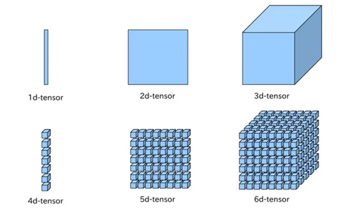

## (4) (N, 100)은 무엇인가?(텐서의 ‘크기’ 읽는 법)

- 딥러닝에서는 데이터의 ’크기(shape)’를 ( )로 표기함.
- (N, 100): 2D 텐서(행렬)
  - N: number of samples(문서의 수) 또는 batch size(한 번에 처리하는 문서 묶음).
  - 100: sequence length(시퀀스 길이)([EX] 우리가 `maxlen=100`으로 정한, 문장 하나에 포함된 단어의 수).
  - 의미: (N, 100)은 “N개의 문서가 있고, 각 문서는 100개의 정수(단어)로 이루어져 있다”는 뜻.
- (N, 100, 200): 3D 텐서
  - N: 문서의 수.
  - 100: 시퀀스 길이(문장 내 단어 수).
  - 200: embedding dimension(임베딩 차원)([EX] 단어 하나를 표현하는 의미 벡터의 차원 수).
  - 의미: “N개의 문서가 있고, 각 문서는 100개의 단어로 이루어져 있으며, 각 단어는 200차원의 의미 벡터로 표현된다”는 뜻(`layer_embedding()`의 **출력** 크기).
- 왜 텐서를 쓰는가?
  - 텍스트 데이터는 ‘문서의 수(배치[batch]의 크기)’, ‘문장의 길이’, ’단어 벡터의 차원’이라는 3가지 ’축’을 갖기 때문에 3D 텐서로 표현하는 것이 가장 자연스러움.
  - 예시
    - 4개의 문장으로 구성된 전체 훈련 데이터가 있다고 가정: [[나는 사과를 좋아해], [나는 바나나를 좋아해], [나는 사과를 싫어해], [나는 바나나를 싫어해]].
    - 컴퓨터는 아직 이 상태로는 ’나는 사과를 좋아해’의 단어가 1개인지 3개인지 이해하지 못함. 우선 컴퓨터의 입력으로 사용하기 위해서는 단어별로 나눠주어야 함. $\rightarrow$ [[‘나는’, ‘사과를’, ‘좋아해’], [‘나는’, ‘바나나를’, ‘좋아해’], [‘나는’, ‘사과를’, ‘싫어해’], [‘나는’, ‘바나나를’, ‘싫어해’]].
    - 이제 훈련 데이터의 크기는 4×3의 크기를 가지는 2D 텐서임. 컴퓨터는 텍스트보다는 숫자를 더 잘 처리할 수 있음. 이에 따라 각 단어를 벡터로 만듦. 아래와 같이 단어를 3차원의 벡터로 변환했다고 가정하자.
      - ‘나는’ = [0.1, 0.2, 0.9].
      - ‘사과를’ = [0.3, 0.5, 0.1].
      - ‘바나나를’ = [0.3, 0.5, 0.2].
      - ‘좋아해’ = [0.7, 0.6, 0.5].
      - ‘싫어해’ = [0.5, 0.6, 0.7].
    - 위 기준을 따라서 훈련 데이터를 재구성하면 아래와 같음.
      - [[[0.1, 0.2, 0.9], [0.3, 0.5, 0.1], [0.7, 0.6, 0.5]],
      - [[0.1, 0.2, 0.9], [0.3, 0.5, 0.2], [0.7, 0.6, 0.5]],
      - [[0.1, 0.2, 0.9], [0.3, 0.5, 0.1], [0.5, 0.6, 0.7]],
      - [[0.1, 0.2, 0.9], [0.3, 0.5, 0.2], [0.5, 0.6, 0.7]]]
    - 이제 훈련 데이터는 4×3×3의 크기를 가지는 3D 텐서임. 이제 batch 크기를 2로 해보자,
      - 첫 번째 배치
        - [[[0.1, 0.2, 0.9], [0.3, 0.5, 0.1], [0.7, 0.6, 0.5]],
        - [[0.1, 0.2, 0.9], [0.3, 0.5, 0.2], [0.7, 0.6, 0.5]]]
      - 두 번째 배치
        - [[[0.1, 0.2, 0.9], [0.3, 0.5, 0.1], [0.5, 0.6, 0.7]],
        - [[0.1, 0.2, 0.9], [0.3, 0.5, 0.2], [0.5, 0.6, 0.7]]]
    - 컴퓨터는 배치 단위로 가져가서 연산을 수행. 그리고 현재 각 배치의 텐서 크기는 (2×3×3)임. $\Rightarrow$ (batch 크기 = 2, 문장 길이 = 3, 단어 벡터의 차원 = 3)의 크기임.

## (5) 핵심 레이어 1: 임베딩 레이어

- 개념: ’정수 인덱스’를 ’의미 벡터’로 변환하는 ’조회 테이블(lookup table)’임.
- 구현함수: `layer_embedding()`.
- 왜 ’테이블’인가?
  - `layer_embedding()` 함수는 레이어 내부에 하나의 큰 표(table)를 만듦.
  - 이 ’표’는 (input_dim, output_dim) 크기의 2D 텐서(행렬)임([EX] (5000단어, 200차원)).
  - [표의 구조]
    - 1행: [0.1, 0.2, …] $\Rightarrow$ 1번 단어(<OOV>)의 200차원 벡터.
    - 2행: [0.5, -0.1, …] $\Rightarrow$ 2번 단어(“문의”)의 200차원 벡터.
    - 3행: [0.9, 0.3, …] $\Rightarrow$ 3번 단어(“배송”)의 200차원 벡터.
    - …
    - 15행: [0.3, -0.7, …] $\Rightarrow$ 15번 단어(“하다”)의 200차원 벡터.
    - …
    - 5000행: [-0,6, 0.8, …] $\Rightarrow$ 5000번 단어의 200차원 벡터.
- 왜 ’조회(lookup)’인가?
  - 모델에 [0, 0, …, 3, 2, 15] (정수 텐서)가 입력되면, 레이어는 이 숫자들을 ’인덱스’로 사용하여 위 ’표’에서 해당 행을 ’조회(lookup)’함.
  - 3 $\Rightarrow$ 3행 [0.9, 0.3, …] $\Rightarrow$ “배송” 벡터를 꺼냄.
  - 2 $\Rightarrow$ 2행 [0.5, -0.1, …] $\Rightarrow$ “문의” 벡터를 꺼냄.
  - 15 $\Rightarrow$ 15행 [0.3, -0.7, …] $\Rightarrow$ “하다” 벡터를 꺼냄.
  - 결과: (N, 100) 크기의 ’정수 텐서’가 (N, 100, 200) 크기의 ’의미 텐서’로 ’차원이 확장’됨.
- 주요 논항
  - `input_dim = 5000`: “조회할 테이블의 행(row) 수가 총 몇 개인가?” $\Rightarrow$ 우리 단어 사전의 크기를 가르쳐줘야 함.
  - `output_dim = 200`: “조회했을 때 꺼내올 벡터의 열(column) 수가 몇 개인가?” $\Rightarrow$ 단어 하나를 몇 차원의 벡터로 표현할지 우리가 결정하는 값.
  - `input_length = 100`: 모델의 다음 레이어에게 “이제 100개의 단어가 한 세트로 들어올 거야”라고 미리 알려주는 것. $\Rightarrow$ 모델 구조를 명확히 함.

**[그림 2] 임베딩 레이어 조회(lookup) 과정**

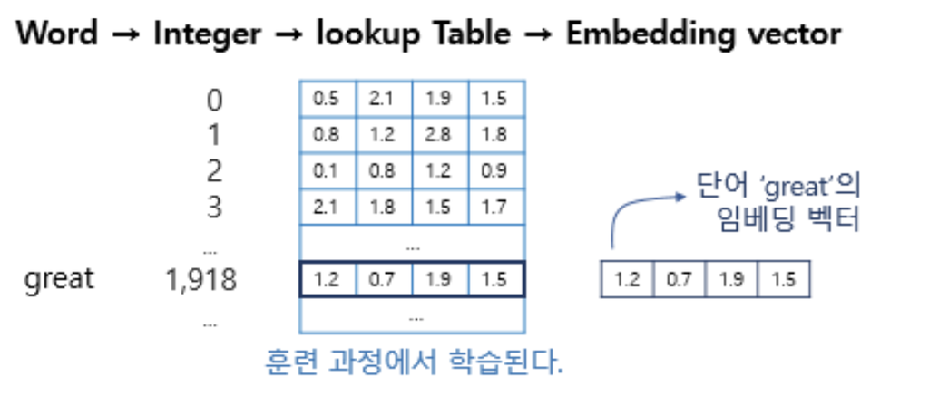

## (6) 핵심 레이어 2: 글로벌 풀링 레이어(global pooling layer)

- 개념: (N, 100, 200) 크기의 ‘단어 벡터 묶음’을 (N, 200) 크기의 ’단일 문장 벡터’로 ’요약’ 또는 ’압축’함.
- 구현함수: `layer_global_average_pooling_1d()`.
- 왜 필요한가?
  - `layer_embedding()`의 출력은 100개 단어 벡터의 ’나열’임.
  - 하지만 우리가 하려는 건 ‘문장’(사실상 띄어쓰기 단위로 연결된 문서) 분류임.
  - 최종 판단을 내릴 `layer_dense()`(바로 뒤에서 상세히 설명)는 100개의 단어 벡터가 아닌, 이 100개를 ‘요약’한 단 하나의 ’문장’ 벡터를 입력으로 받아야 함.
- 작동방식(`_average_`): 100개 단어 벡터의 각 차원(200개)별로 ’평균’을 냄.
  - 비유: 100개의 ‘재료(단어)’를 믹서기에 넣고 갈아 ’평균’ 맛의 ‘주스(문장)’ 하나를 만드는 것과 같음.
  - 단점: 단어의 ’순서’를 완전히 무시함([EX] “배송 문의”와 “문의 배송”을 똑같이 취급).
  - (문서당 단어 수에 제한을 두는) 단어 임베딩을 사용하면, 긴 문서를 대상으로 한 딥러닝은 어려운가?”
    - `layer_global_average_pooling_1d()`을 쓰면 어려움. 단어의 순서와 맥락이 모두 파괴되기 때문.
    - 이 ‘평균’ 방식의 한계를 느껴야만, 다음 시간에 ’순서’를 학습하는 RNN/LSTM/BERT를 배울 필요성을 공감하게 될 것.

## (7) 핵심 레이어 3: 밀집 레이어(dense layer)

- 개념: 딥러닝의 ‘두뇌’ 또는 ‘결정자’. 입력된 벡터(숫자들)를 ’가중치(weight)’와 ’활성화 함수(activation function)’를 통해 변환하고 결정을 내리는 핵심부품임.
- 구현함수: `layer_dense()`.
- 왜 필요한가?
  - 지금까지 우리는 ‘문장 벡터’(N, 200)를 만들었음.
  - 이제 이 200개 숫자(문장의 의미)를 보고, “이건 AS(0)에 가까워, 아니면 배송(1)에 가까워?”를 **판단**할 ’결정자’가 필요함.
- 핵심 용어와 논항
  - `units`
    - 개념: ‘뉴런(neuron)’ 또는 ’노드(node)’의 수.
    - 뉴런/노드: ‘계산기’ 하나라고 생각하면 됨. 이 계산기는 입력된 200개 숫자에 ’가중치(w)’를 곱하고 ’편향(b)’을 더하는 (y = w * x + b) 계산을 함.
      - 가중치(weight, w)
        - 개념: 입력값의 중요도. 각 뉴런(계산기)은 200개의 입력 각각에 대해 “이 입력이 얼마나 중요한지”를 나타내는 ’가중치’를 부여함.
        - [EX] 문장 벡터 200개 중 1번 특성은 0.5만큼, 2번 특성은 1.2만큼 중요하다고 판단. $\Rightarrow$ 이 w 값들이 딥러닝이 학습하는 핵심 매개변수임.
      - 편향(bias, b): 기본점수 또는 기준점. y 절편에 비유할 수 있음. 입력값(x)이 모두 0이더라도 뉴런이 기본적으로 갖는 ‘활성화 기준값’. 이 b 값도 딥러닝이 학습하는 매개변수임.
    - `units = 32`의 의미: “이 (y = w * x + b) 계산기 세트를 32개 만들겠다”는 뜻. 200개의 숫자를 32개의 ‘더 의미 있는’ 숫자로 요약함.
    - `units = 5`의 의미: “이 레이어에 5개의 계산기를 두겠다”는 뜻. 왜 5개? 우리가 맞춰야 할 주제(라벨)가 5개(AS, 제품, 주문, 배송, 환불)이기 때문!
  - `activation`
    - activation function(활성화 함수): 위 ‘계산기’(y = w * x + b)의 결과에 ’추가적인 처리’를 하는 함수임.
    - 왜 필요한가: y = w * x + b는 ‘선형(linear)’ 계산(데이터를 ‘직선’으로만 자르려는 시도)임. 하지만 “AS”와 “배송” 문제는 ’직선’ 하나로 나눌 수 없는 ‘비선형(non-linear)’ 문제일 수 있음.
    - `activation = "relu"`: 가장 인기 있는 ‘비선형’ 활성화 함수
      - 작동: `relu` $\Rightarrow$ 계산결과가 음수(-)면 0으로 만들고, 양수(+)면 그대로 내보냄.
      - 역할: 이 단순한 처리만으로도 모델이 ’직선’이 아닌 ’구부러진 선’으로 데이터를 나눌 수 있게 함(모델의 표현력 증가).
    - `activation = "softmax"`: 마지막 레이어에서만 사용하는 특별한 활성화 함수.
      - 역할: `units = 5` 계산기에서 나온 5개의 숫자([EX] [1.2, -0.5, 3.0, 0.1, 0.8])를 ‘확률’([EX] [0.1, 0.05, 0.7, 0.05, 0.1])로 변환함.
      - 특징: 확률의 총합이 1이 됨([EX] 70% 확률로 “주문” 주제라고 판단).

**[그림 3] 뉴런, 가중치, 편향, 활성화 함수**

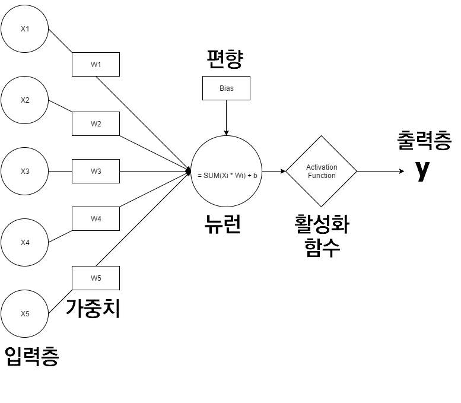

## (8) 핵심 레이어 4: 드롭아웃 레이어(dropout layer)

- 개념: 모델이 과적합(overfitting)되는 것을 방지하기 위한 규제(regularization) 장치.
- 구현함수: `layer_dropout()`.
- 과적합: 모델이 훈련 데이터(`x_train`)는 너무 잘 맞춰서 ‘정답을 외워버리고’, 정작 처음 보는 테스트 데이터(`x_test`)에서는 성능이 나쁘게 나오는 현상. $\Rightarrow$ 족보만 달달 외워서 응용문제를 못 푸는 학생.
- 왜 필요한가: `layer_dense()`의 뉴런(계산기)들이 너무 잘 협력해서 정답을 외우는 것을 방지해야 하기 때문.
- 작동방식: 학습(training) 중에만 일부 뉴런(계산기)을 무작위로 꺼버림(비활성화).
- 주요 논항
  - `rate`: `rate = 0.3` $\Rightarrow$ “학습할 때마다 30%의 뉴런을 무작위로 꺼라”라는 뜻.
  - 효과: 모델이 특정 뉴런에 의존하지 않고, 다양한 방식으로 정답을 찾는 법을 배우게 되어 응용력(일반화 성능)이 좋아짐.

## (9) Keras 전처리 4단계

# 5. Keras 전처리

- 이제 4.9절에서 배운 4대 함수를 실제로 적용해볼 차례!
- `to_categorical()` 함수
- 왜 필요한가: 앞서 라벨을 0, 1, 2, 3, 4(숫자)로 만들었음.
- 문제점: 딥러닝 모델은 숫자를 ‘크기’로 오해할 수 있음([EX] ’환불’(4)이 ‘AS’(0)보다 4배 더 중요한가?).
- 해결책: 원-핫 인코딩(one-hot encoding) $\Rightarrow$ `to_categorical()` 함수는 숫자를 원-핫 벡터로 변환함.
  - 0(“AS문의”) $\rightarrow$ [1, 0, 0, 0, 0].
  - 1(“배송”) $\rightarrow$ [0, 1, 0, 0, 0].
  - …
  - 4(“환불”) $\rightarrow$ [0, 0, 0, 0, 1].
- 이유: 이래야 `activation = "softmax"`와 ‘짝’이 맞음. $\Rightarrow$ `softmax`가 5개 확률 [0.1, 0.05, 0.7, 0.05, 0.1]을 출력하면, Keras는 이 ’예측’이 ’정답’([EX] [0, 0, 1, 0, 0])과 얼마나 유사한지(근접한지) 비교하여 학습함.

```r
# ===================================================================
# 4. [실습 4] Keras 전처리 (토큰화, 패딩, 라벨 변환)
# ===================================================================
load("deeplearning.dataset_tokenized.rda")

# --- 하이퍼파라미터 설정 ---
# (모델 성능에 영향을 주는 주요 변수들)

# 단어 사전에 포함할 최대 단어 수 (빈도수 기준 상위 5000개)
vocab_size <- 5000
# 문장 최대 길이(100개 단어). 이보다 길면 자르고, 짧으면 0으로 채움.
maxlen <- 100
# 임베딩 벡터 차원(실습 4의 Word2Vec 모델 차원과 일치시킬 것)
embedding_dim <- 200
# -----------------------------

# (1) Keras 토크나이저 생성(text_tokenizer())
# (빈 깡통 만들기: 최대 5000개, 5000등 밖은 <OOV>)
py_require_legacy_keras()
tokenizer <- text_tokenizer(num_words = vocab_size, oov_token = "<OOV>")

# (2) 단어 사전(vocabulary) 생성(fit_text_tokenizer())
# (빈 깡통에 우리 데이터(deeplearning.dataset_tokenized$text)를 넣어 채우기)
fit_text_tokenizer(tokenizer, deeplearning.dataset_tokenized$text)

# (3) 텍스트 -> 정수 시퀀스 변환(texts_to_sequences())
# (완성된 사전으로 "배송 문의" -> list(c(3, 2)) 번역)
sequences <- texts_to_sequences(tokenizer, deeplearning.dataset_tokenized$text)

# (4) 패딩(padding)(pad_sequences())
# (모든 문장을 100칸짜리 틀에 맞추기. 짧으면 앞에 0 추가)
x_data <- pad_sequences(sequences, maxlen = maxlen, padding = "pre")

# (5) 라벨(y) 원-핫 인코딩(to_categorical())
# (Keras 모델은 0~4 정수 대신 [0,0,1,0,0] 같은 원-핫 라벨을 선호함)
# ([EX] "배송"(1) -> [0, 1, 0, 0, 0])
# (이유: 'categorical_crossentropy()' 손실함수는 이 형태를 요구함)
y_data <- to_categorical(deeplearning.dataset_tokenized$label_numeric, num_classes = 5)

# (6) 훈련/테스트 데이터 분리(80% 훈련, 20% 테스트)
# (재현성을 위해 set.seed 고정)
set.seed(123)
# 1:nrow(x_data)(전체 행 번호) 중에서 80% 만큼을 무작위로 뽑아서 훈련용 인덱스(행 번호 목록)로 사용
train_indices <- sample(1:nrow(x_data), size = round(0.8 * nrow(x_data)))

# 훈련 데이터(전체의 80%)
# x_data 행렬에서 'train_indices'에 해당하는 '행'들만 선택함
x_train <- x_data[train_indices, ] # 훈련용 X(정수 행렬).

# y_data 행렬에서 'train_indices'에 해당하는 '행'들만 선택함
y_train <- y_data[train_indices, ] # 훈련용 Y(원-핫 행렬).

# 테스트 데이터(전체의 20%)
# (-train_indices: 훈련용 인덱스를 '제외한' 나머지 20%)
x_test <- x_data[-train_indices, ] # 테스트용 X.
y_test <- y_data[-train_indices, ] # 테스트용 Y.
```

# 6. **Word2Vec**과 Keras의 연결

## (1) 사전학습 임베딩(**Word2Vec**) 로드

- 함수: `gensim$models$Word2Vec$load(model_path)`
  - `ko.bin`과 같은 Word2Vec 사전학습 모델을 로드함.
  - `w2v_model$wv$similarity("우울", "불안")`: 두 단어의 의미 유사도를 확인함.
- 함수: `gensim$models$FastText$load_fasttext_format(model_path)`
  - `cc.ko.300.bin`과 같은 FastText 사전학습 모델을 로드함.
  - `w2v_model_ft$similarity("우울", "불안")`: 두 단어의 의미 유사도를 확인함.

```r
# ===================================================================
# 5. [실습 5] 사전학습 Word2Vec 2종 로드
# ===================================================================

# (1) reticulate를 통해 파이썬의 'gensim' 라이브러리를 R로 불러옴
gensim <- import("gensim")

# (2) 사전학습 모델 파일의 경로를 지정함(반드시 워킹 디렉토리에 해당 파일이 있어야 함)
model_path <- "ko.bin"

# (3) gensim의 Word2Vec 모델 로드 함수를 호출하여 'ko.bin' 파일을 R 메모리로 불러옴
w2v_model <- gensim$models$Word2Vec$load(model_path)

# (4) (테스트) '우울'과 '불안'의 의미 유사도 확인
w2v_model$wv$similarity("우울", "불안")
```

```
## [1] 0.5350148
```

```r
# (5) 로드한 모델('w2v_model')의 'wv'(word vector) 속성에서 'vector_size'(차원 수, [EX] 200)를 가져옴
embedding_dim_w2v <- w2v_model$wv$vector_size

# (6) 이 값을 앞서 설정한 Keras용 'embedding_dim' 변수에 덮어씀
# (이유: embedding_dim=200과 ko.bin의 차원이 다를 수 있으므로)
embedding_dim <- embedding_dim_w2v

# (7) FastText의 cc.ko.300.bin 파일 경로 지정
model_path_ft <- "cc.ko.300.bin"

# (8) cc.ko.300.vec 텍스트 파일을 load_fasttext_format으로 로드(용량이 커서 시간이 오래 걸림)
w2v_model_ft <- gensim$models$FastText$load_fasttext_format(
  model_path_ft
) # 만약 RAM 용량이 작아서 로드 오류가 나는 경우 사용하지 않는 것을 추천. ko.bin만으로도 비슷한 성능을 기대할 수 있음.

# (9) (테스트) '우울'과 '불안'의 의미 유사도 확인
w2v_model_ft$similarity("우울", "불안") # 0.573369
```

```
## [1] 0.573369
```

```r
# (10) 로드한 모델(w2v_model_ft)의 "사랑" 벡터를 R 숫자 벡터로 변환(as.numeric) 후,
# R의 length() 함수로 길이를 직접 측정
sample_vec <- as.numeric(w2v_model_ft[["사랑"]])
embedding_dim_w2v_ft <- length(sample_vec)

# (11) 이 값을 Keras용 'embedding_dim_ft' 변수에 덮어씀
embedding_dim_ft <- embedding_dim_w2v_ft
```

## (2) 임베딩 행렬 구축

- 설명: **keras**의 `tokenizer$word_index`(부품 목록 [EX] “배송”=3)와 **gensim**의 `w2v_model$wv`(부품 통 [EX] “배송”=[0.12, -0.54, …])을 연결함.
- `embedding_matrix`(우리의 목표): (5000, 200) 크기의 ‘빈 상자’를 만들고, `word_index`의 순서대로 `w2v_model`/`w2v_model_ft`에서 벡터를 꺼내와 채워넣는 ’키트’ 제작과정임.
- for 루프 로직
  1. `word_index`에서 단어([EX] “배송”)와 인덱스([EX] 3)를 가져옴.
  2. `w2v_model`/`w2v_model_ft`에 “배송”이 있는지 확인.
  3. 있으면 `w2v_model`/`w2v_model_ft`에서 “배송”의 벡터(200/300차원)를 꺼냄.
  4. `embedding_matrix`의 세 번째 행에 이 벡터를 복사해 집어넣기.

```r
# ===================================================================
# 6. [실습 6] 임베딩 행렬 구축
# ===================================================================

# (1) (실습 4에서 만든) Keras 토크나이저의 '단어:인덱스' 목록을 가져옴
# ([EX] list("문의"=2, "배송"=3, ...))
word_index <- tokenizer$word_index

# (2) 임베딩 행렬의 '행' 크기를 Keras 사전 크기(5000)로 설정함
embedding_matrix_rows <- vocab_size

# (3) (5000, 200) 크기의 '모든 값이 0인' 빈 R 행렬(매트릭스)을 생성함('빈 키트')
embedding_matrix <- matrix(0, nrow = embedding_matrix_rows, ncol = embedding_dim)
embedding_matrix_ft <- matrix(0, nrow = embedding_matrix_rows, ncol = embedding_dim_ft)

# (4) gensim의 vocab 객체(dict)에서 '키' 목록을 가져와 R의 '문자열 벡터'로 미리 변환하기
# (names()만 쓰면 Python 객체가 반환되어 %in% 오류 발생)
w2v_vocab_list <- as.character(names(w2v_model$wv$vocab))
w2v_vocab_list_ft <- py_to_r(w2v_model_ft$wv$index2word)

# (5-1) '부품 목록'(word_index)을 보며 '부품 통'(w2v_model)에서 꺼내오기
# (names(word_index)는 "문의", "배송", ... 단어 리스트)
for (word in names(word_index)) {

  # 1) 현재 단어(word)의 정수 인덱스(index)를 조회함([EX] 3)
  index <- word_index[[word]]

  # 2) 이 인덱스가 우리가 정한 상위 5000개 안에 드는지 확인
  if (index < vocab_size) {

    # 3) 이 단어(word)가 gensim 모델('부품 통')에도 존재하는지 확인
    # (w2v_vocab_list는 w2v 모델의 전체 단어 리스트임)
    if (word %in% w2v_vocab_list) {

      # 4) (존재한다면) gensim 모델에서 해당 단어의 '의미 벡터'(200차원)를 꺼냄
      embedding_vector <- as.numeric(w2v_model$wv[[word]])

      # 5) '빈 키트'(embedding_matrix)의 'index' 번째 행([EX] 3번 행)에다 꺼내온 벡터를 '복사'해 집어넣기
      embedding_matrix[index, ] <- embedding_vector
    }
    # 6) (만약 word가 w2v_model에 없으면? '빈 키트'의 해당 행은 그냥 0 벡터인 채로 유지됨)
  }
}

# (5-2) '부품 목록'(word_index)을 보며 '부품 통'(w2v_model_ft)에서 꺼내오기
# (names(word_index)는 "문의", "배송", ... 단어 리스트)
for (word in names(word_index)) {

  # 1) 현재 단어(word)의 정수 인덱스(index)를 조회함([EX] 3)
  index <- word_index[[word]]

  # 2) 이 인덱스가 우리가 정한 상위 5000개 안에 드는지 확인
  if (index < vocab_size) {

    # 3) 이 단어(word)가 gensim 모델('부품 통')에도 존재하는지 확인
    # (w2v_vocab_list_ft Fasttext 모델의 전체 단어 리스트임)
    if (word %in% w2v_vocab_list_ft) {

      # 4) (존재한다면) gensim 모델에서 해당 단어의 '의미 벡터'(200차원)를 꺼냄
      embedding_vector_ft <- as.numeric(w2v_model_ft[[word]])

      # 5) '빈 키트'(embedding_matrix_ft)의 'index' 번째 행([EX] 3번 행)에다 꺼내온 벡터를 '복사'해 집어넣기
      embedding_matrix_ft[index, ] <- embedding_vector_ft
    }
    # 6) (만약 word가 w2v_model_ft에 없으면? '빈 키트'의 해당 행은 그냥 0 벡터인 채로 유지됨)
  }
}
```

# 7. 딥러닝 모델 ‘학습’ 3단계: compile(), fit(), evaluate()

- 모델을 만들고 학습시키기 전에 `compile()`, `fit()`, `evaluate()` 이 세 가지 핵심함수가 ‘왜’ 필요한지 알아야 함.
- Keras는 모델 구축(`keras_model_sequential()`)과 학습(`fit()`) 과정을 분리함. 그 사이에 설정(`compile()`) 단계가 필요함.

## (1) [1단계] compile() 함수: ‘학습계획’ 설정하기

- 역할: `fit()` 함수가 ‘어떻게’ 학습해야 할지 ‘학습방식(계획)’을 설정함(비유: 빵을 굽기 전 ’오븐 온도’, ‘굽는 시간’, ’평가기준’에 관한 레시피 만들기).
- 딥러닝의 ’학습’이란 무엇인가?
  - 개념: loss(손실함수 = 오차 = 벌점)를 최소화하는 ‘최적의’ 가중치(w)와 편향(b) 값을 자동으로 찾아가는 과정임.
  - 이 과정은 `fit()` 함수가 실행될 때 `compile()`에 설정된 계획표대로 진행됨
    - 1. 예측(forward pass): `x_train` 데이터를 모델에 넣고 현재의 w, b로 ’예측확률’을 계산함.
    - 2. 오차계산(loss calculation): 손실함수가 ‘예측확률’([EX] [0.1, 0.05, 0.7, 0.05, 0.1])과 ‘실제 정답’([EX] [0, 0, 1, 0, 0])을 비교하여 ‘오차(error)’ 점수를 계산함.
    - 3. 역전파(backpropagation) 및 업데이트
      - 옵티마이저(optimizer)가 이 ‘오차 값’([EX] 0.3)을 확인.
      - 옵티마이저는 “아, 세 번째 값이 1.0이 나와야 하는데 0.7밖에 안 나왔네. 오차가 0.3이나 있군. 이 오차를 줄이려면 1번 레이어(`layer_embedding()`)부터 마지막 레이어(`layer_dense()`)까지, 이 계산에 사용된 모든 w와 b 값을 어떻게 바꿔야 할까?”를 역으로 계산. $\Rightarrow$ 이것이 바로 역전파!
      - 옵티마이저는 “이 w 값은 0.001만큼 높이고”, “이 b 값은 0.002만큼 낮추고”… 와 같이 모델의 모든 w와 b를 아주 조금씩 수정(업데이트)함.
- 주요 논항
  - `optimizer`: [EX] `"adam"`. 어떻게 w, b를 업데이트할 것인가?(최적화 도구) $\Rightarrow$ ‘오차’라는 산을 가장 빨리 내려가기 위한 ’등산기술’. `"adam"`은 가장 표준적이고 성능 좋은 ’등산기술’임.
  - `loss`: [EX] `"categorical_crossentropy"`. 무엇을 기준으로 학습할 것인가?(손실함수)
    - 비유: ‘틀린 정도’를 측정하는 ’벌점(penalty)’. 위 2번 단계에서 ’오차’를 계산하는 방식임.
    - 모델은 이 loss(벌점)를 최소화하는 방향으로 w, b를 업데이트함.
    - `categorical_crossentropy`: `softmax` 출력과 원-핫 라벨을 비교할 때 사용하는 표준 오차 계산법임.
  - `metrics`: [EX] `c("accuracy")`: 무엇을 모니터링할 것인가?(평가지표) $\Rightarrow$ 학습과정(epoch)마다 “현재 정확도가 몇 %인지” 보여주는 ‘계기판’. `loss`는 기계가 학습에 사용하는 숫자라면, `accuracy`는 사람이 이해하는 숫자임.

## (2) [2단계] fit() 함수: ‘학습’ 실행하기

- 역할: `compile()`에서 설정한 ’학습계획’대로 실제 ’학습’을 실행함(비유: ’오븐’에 반죽을 넣고 굽기 시작).
- 주요 논항
  - `x_train`: 훈련용 문제지.
  - `y_train`: 훈련용 정답지.
  - `epochs`: [EX] `epochs = 10`. $\Rightarrow$ 훈련 데이터를 몇 번 반복해서 볼 것인지 정함(비유: 교과서를 10번 정독).
    - `epoch = 1`은 훈련 데이터 전체([EX] 5,000개)를 처음부터 끝까지 한 번 훑어보는 것을 의미함. 딥러닝 모델은 처음엔 랜덤 값(w, b)에서 시작하므로, 데이터를 한 번만 봐서는 충분히 똑똑해지지 않음(w, b가 최적이 아님).
    - 모델은 `epoch = 1`에서 데이터를 훑어보며 w, b를 약간 수정함. `epoch = 2`에서는 약간 똑똑해진 w, b를 가지고 같은 데이터를 다시 훑어보며 w, b를 더욱 정교하게 수정함.
    - `epochs = 10`은 “더 나은 w, b를 찾기 위해(오차를 더 줄이기 위해) 전체 교과서를 10번 반복 학습하겠다”는 의미임(즉 이 정교화 과정을 10번 반복함).
  - `batch_size`: [EX] `batch_size = 32` $\Rightarrow$ `epoch = 1`을 진행할 때, 5,000개 데이터를 한꺼번에 메모리에 올릴 수 없음(메모리 부족 문제).
    - 데이터를 ‘32개씩 묶어서’ 학습하고 가중치를 업데이트함(비유: 5,000문제를 32문제씩 쪼개서 풀고, 32문제마다 오답노트[w, b 업데이트]를 씀).
    - 1 Epoch에는 (5000 / 32) = 약 157번의 ‘오답 노트 작성(w, b 업데이트)’ 과정이 일어남.
  - `validation_split`
    - [EX] `validation_split = 0.2` $\Rightarrow$ ’과적합’을 감시하기 위한 목적. 훈련 데이터(`x_train`)에서 20%를 떼어내어, epoch마다 모의고사를 보는 용도로 사용함.
    - 만약 훈련 정확도(`accuracy`)는 오르는데, 검증 정확도(`val_accuracy`)가 떨어지면 ’과적합’이 시작됐다는 신호!

## (3) [3단계] evaluate() 함수: ’최종평가’하기

- 역할: 학습이 끝난 모델(`fit()`이 완료된 모델)에, 학습 중에 한 번도 본 적 없는 ‘테스트 데이터’(`x_test`, `y_test`)를 주어 최종성능을 평가함.
- 비유: `fit()`은 훈련과 모의고사(validation)를 보는 과정이고, `evaluate()`는 실제 수능을 보는 것. 이 점수가 모델의 진짜 실력임.
- 왜 `validation_split`과 다른가?
  - `validation_split`으로 떼어낸 ‘검증 데이터’는 모델이 학습(w, b 업데이트)에 직접 사용하진 않지만, ’언제 학습을 멈출지’ 또는 ’어떤 epoch일 때 최고 성능인지’를 참고하는 용도로 쓰임. 즉 모델이 이 데이터로부터 간접적으로 영향을 받음.
  - `x_test`, `y_test` 데이터는 모델이 학습하는 동안 단 한 번도 보지 못한 데이터임.
  - 따라서 `evaluate(x_test, y_test)`의 결과가 이 모델의 ’진정한 일반화 성능’을 나타내는 가장 객관적인 지표임.
- 주요 논항
  - `x_test`: 수능 문제지.
  - `y_test`: 수능 정답지.
  - `verbose`
    - `0`: 평가과정(progress bar)은 보여주지 말고, 최종점수(loss와 accuracy)만 조용히(`verbose = 0`) 알려달라는 뜻
    - `1`: 진행막대 표시.

# 8. 지도학습 분류 모델 구축

## (1) 시나리오 1: 임베딩을 처음부터 학습(scratch)

- 비유: 한국어를 전혀 모르는 신입사원. `layer_embedding()`이 랜덤 값으로 초기화되며, 우리 데이터(5,000건)만으로 ’배송’과 ’문의’의 의미를 **처음부터** 학습해야 함.

```r
# ===================================================================
# 7. [실습 7] 시나리오 1: 임베딩을 '처음부터' 학습(train from the scratch)
# ===================================================================
# k_clear_session(): 이전 모델이 메모리에 남아있다면 정리
k_clear_session()

# (0) keras_model_sequential(): '레고 바닥판' 준비
model_scratch <- keras_model_sequential(name = "Model_Scratch") %>%

  # (1) 임베딩 레이어
  # (랜덤 값으로 초기화된 (5000, 200) '조회 테이블' 생성)
  layer_embedding(
    input_dim = embedding_matrix_rows, # Keras 사전 크기(5000)
    output_dim = embedding_dim, # 임베딩 차원(200)
    input_length = maxlen, # 문장 길이(100)
    trainable = TRUE # 이 '조회 테이블'도 '학습'하라(중요)
  ) %>%

  # (2) 문장 벡터화(pooling)
  # (N, 100, 200) -> (N, 200)으로 '평균' 내어 압축
  layer_global_average_pooling_1d() %>%

  # (3) 분류기
  # (200개 숫자를 32개로 요약)
  layer_dense(units = 32, activation = "relu") %>% # 중간층(비선형성 추가)

  # 1) 드롭아웃 레이어
  # (과적합 방지를 위해 30%의 뉴런을 랜덤하게 끔)
  layer_dropout(rate = 0.3) %>%

  # 2) 최종 출력층
  # (32개 숫자를 5개 주제에 대한 '확률'로 변환)
  layer_dense(units = 5, activation = "softmax")

# (4) 모델 컴파일('학습계획' 설정)
model_scratch %>% compile(
  # 'adam' 최적화 도구 사용(w, b 업데이트 방식)
  optimizer = "adam",
  # 원-핫 라벨용 손실함수 사용(to_categorical()과 짝)
  loss = "categorical_crossentropy",
  # 계기판에 정확도 표시
  metrics = c("accuracy")
)
summary(model_scratch) # 모델 구조 확인.
```

```
## Model: "Model_Scratch"
## ________________________________________________________________________________
##  Layer (type)                       Output Shape                    Param #
## ================================================================================
##  embedding (Embedding)              (None, 100, 200)                1000000
##  global_average_pooling1d (GlobalAv  (None, 200)                    0
##  eragePooling1D)
##  dense_1 (Dense)                    (None, 32)                      6432
##  dropout (Dropout)                  (None, 32)                      0
##  dense (Dense)                      (None, 5)                       165
## ================================================================================
## Total params: 1,006,597
## Trainable params: 1,006,597
## Non-trainable params: 0
## ________________________________________________________________________________
```

```r
# (5) 모델 학습 ('학습' 실행)
history_scratch <- model_scratch %>% fit(
  x_train, y_train, # 훈련 데이터 (문제지와 정답지).
  epochs = 10, # 훈련 데이터를 10번 반복학습.
  batch_size = 32, # 32개씩 묶어서 학습(w, b 업데이트).
  validation_split = 0.2, # 훈련 데이터 중 20%로 '모의고사' 보기.
  verbose = 2, # 학습 로그 간소화(1=상세, 2=간략, 0=끄기).
  callbacks = list(
        callback_early_stopping(
          monitor = "val_accuracy",
          patience = 3,
          restore_best_weights = TRUE  # 최고 val_accuracy의 가중치로 되돌림.
        )
      )
)
```

```
## 100/100 - 2s - loss: 1.5966 - accuracy: 0.2587 - val_loss: 1.5631 - val_accuracy: 0.5275 - 2s/epoch - 19ms/step
## 100/100 - 1s - loss: 1.4836 - accuracy: 0.4516 - val_loss: 1.3698 - val_accuracy: 0.5475 - 1s/epoch - 11ms/step
## 100/100 - 1s - loss: 1.2410 - accuracy: 0.5659 - val_loss: 1.1129 - val_accuracy: 0.6587 - 1s/epoch - 11ms/step
## 100/100 - 1s - loss: 1.0013 - accuracy: 0.6609 - val_loss: 0.9307 - val_accuracy: 0.7200 - 1s/epoch - 11ms/step
## 100/100 - 1s - loss: 0.8017 - accuracy: 0.7541 - val_loss: 0.8040 - val_accuracy: 0.7675 - 1s/epoch - 11ms/step
## 100/100 - 1s - loss: 0.6685 - accuracy: 0.7953 - val_loss: 0.7220 - val_accuracy: 0.7850 - 1s/epoch - 11ms/step
## 100/100 - 1s - loss: 0.5731 - accuracy: 0.8306 - val_loss: 0.6759 - val_accuracy: 0.8062 - 1s/epoch - 11ms/step
## 100/100 - 1s - loss: 0.5085 - accuracy: 0.8503 - val_loss: 0.6636 - val_accuracy: 0.7962 - 1s/epoch - 11ms/step
## 100/100 - 1s - loss: 0.4587 - accuracy: 0.8672 - val_loss: 0.6495 - val_accuracy: 0.8037 - 1s/epoch - 11ms/step
## 100/100 - 1s - loss: 0.4173 - accuracy: 0.8794 - val_loss: 0.6288 - val_accuracy: 0.8175 - 1s/epoch - 11ms/step
```

```r
# (6) 테스트 데이터로 최종 평가('실제 수능' 보기)
# (학습에 사용되지 않은 x_test, y_test로 '진짜 실력' 평가)
eval_scratch <- model_scratch %>% evaluate(
  x_test, # 수능 문제지.
  y_test, # 수능 정답지.
  verbose = 0 # 조용히 채점.
)
eval_scratch
```

```
##      loss  accuracy
## 0.6615267 0.7920000
```

## (2) 시나리오 2: 사전학습 임베딩 + 미세조정(finetune)

- 비유: 한국어 ‘능통자’(**Word2Vec**) 채용. **Word2Vec**의 일반 지식으로 시작해서 우리 데이터에 맞게 `trainable = TRUE`로 조금씩 벡터를 수정(미세조정)함.
- `set_weights(list(embedding_matrix))`: `layer_embedding()`의 초기값을 랜덤이 아닌 `embedding_matrix`로 주입.
- `name = "sentence_vector_extractor"`: 비지도학습에서 이 층을 재사용하기 위해 이름을 부여함.

```r
# ===================================================================
# 8. [실습 8] 시나리오 2: 사전학습 + 미세조정(pre-trained + fine-tuning)
# ===================================================================

### ko.bin 기반 사전학습 + 미세조정 ###

# 메모리 정리
k_clear_session()

# (0) '바닥판' 준비
model_finetune <- keras_model_sequential(name = "Model_Finetune") %>%

  # (1) 임베딩 레이어(구조는 동일)
  layer_embedding(
    input_dim = embedding_matrix_rows, # 5000
    output_dim = embedding_dim, # 200
    input_length = maxlen, # 100
    # 미세조정을 위해 TRUE로 지정
    # (w, b를 업데이트하라는 의미)
    # (만약 FALSE면 '동결(freeze)'이라 부름)
    trainable = TRUE
  ) %>%

  # (2) 문장 벡터화(pooling)
  # 비지도학습에 재사용하기 위해 레이어에 이름을 부여
  layer_global_average_pooling_1d(name = "sentence_vector_extractor") %>%

  # (3) 분류기(동일)
  layer_dense(units = 32, activation = "relu") %>%
  layer_dropout(rate = 0.3) %>%
  layer_dense(units = 5, activation = "softmax")

# 모델의 임베딩 레이어(1번 레이어)에 embedding_matrix를 가중치로 주입
# 랜덤 초기화 대신, 우리가 만든 '키트'로 교체!
get_layer(model_finetune, index = 1) %>%
  set_weights(
    # (반드시 list()로 한 번 감싸줘야 함)
    list(embedding_matrix)
  )

# (4) 모델 컴파일('학습계획' 설정)
model_finetune %>% compile(
  # 'adam' 최적화 도구 사용(w, b 업데이트 방식)
  optimizer = "adam",
  # 원-핫 라벨용 손실함수 사용
  loss = "categorical_crossentropy",
  # 계기판에 정확도 표시
  metrics = c("accuracy")
)

summary(model_finetune) # 모델 구조 확인.
```

```
## Model: "Model_Finetune"
## ________________________________________________________________________________
##  Layer (type)                       Output Shape                    Param #
## ================================================================================
##  embedding (Embedding)              (None, 100, 200)                1000000
##  sentence_vector_extractor (GlobalA  (None, 200)                    0
##  veragePooling1D)
##  dense_1 (Dense)                    (None, 32)                      6432
##  dropout (Dropout)                  (None, 32)                      0
##  dense (Dense)                      (None, 5)                       165
## ================================================================================
## Total params: 1,006,597
## Trainable params: 1,006,597
## Non-trainable params: 0
## ________________________________________________________________________________
```

```r
# (5) 모델 학습('학습' 실행)
history_finetune <- model_finetune %>% fit(
  x_train, y_train, # 훈련 데이터(문제지와 정답지)
  epochs = 10, # 10번 반복
  batch_size = 32, # 32개씩 묶어서 학습
  validation_split = 0.2, # 20% 모의고사
  verbose = 2, # 간략히 보기
  callbacks = list(
        callback_early_stopping(
          monitor = "val_accuracy",
          patience = 3,
          restore_best_weights = TRUE  # 최고 val_accuracy의 가중치로 되돌림.
        )
      )
)
```

```
## 100/100 - 2s - loss: 1.5688 - accuracy: 0.2975 - val_loss: 1.4832 - val_accuracy: 0.4837 - 2s/epoch - 23ms/step
## 100/100 - 1s - loss: 1.4093 - accuracy: 0.4697 - val_loss: 1.3089 - val_accuracy: 0.5425 - 1s/epoch - 11ms/step
## 100/100 - 1s - loss: 1.2503 - accuracy: 0.5487 - val_loss: 1.1494 - val_accuracy: 0.6225 - 1s/epoch - 11ms/step
## 100/100 - 1s - loss: 1.0967 - accuracy: 0.6166 - val_loss: 1.0124 - val_accuracy: 0.6737 - 1s/epoch - 11ms/step
## 100/100 - 1s - loss: 0.9702 - accuracy: 0.6741 - val_loss: 0.9227 - val_accuracy: 0.7050 - 1s/epoch - 11ms/step
## 100/100 - 1s - loss: 0.8764 - accuracy: 0.7116 - val_loss: 0.8509 - val_accuracy: 0.7262 - 1s/epoch - 11ms/step
## 100/100 - 1s - loss: 0.7813 - accuracy: 0.7453 - val_loss: 0.8084 - val_accuracy: 0.7437 - 1s/epoch - 11ms/step
## 100/100 - 1s - loss: 0.7177 - accuracy: 0.7719 - val_loss: 0.7579 - val_accuracy: 0.7550 - 1s/epoch - 11ms/step
## 100/100 - 1s - loss: 0.6609 - accuracy: 0.7862 - val_loss: 0.7382 - val_accuracy: 0.7650 - 1s/epoch - 11ms/step
## 100/100 - 1s - loss: 0.6079 - accuracy: 0.8119 - val_loss: 0.7155 - val_accuracy: 0.7588 - 1s/epoch - 11ms/step
```

```r
# (6) 테스트 데이터로 최종평가('실제 수능' 보기)
eval_finetune <- model_finetune %>% evaluate(
  x_test, # '수능 문제지'
  y_test, # '수능 정답지'
  verbose = 0 # '조용히 채점'
)
eval_finetune
```

```
##      loss  accuracy
## 0.7410282 0.7690000
```

```r
### cc.ko.300.bin 기반 사전학습 + 미세조정 ###

k_clear_session()
model_finetune_ft <- keras_model_sequential(name = "Model_Finetune") %>%
  layer_embedding(
    input_dim = embedding_matrix_rows, # 5000
    output_dim = embedding_dim_ft, # 300
    input_length = maxlen, # 100
    trainable = TRUE
  ) %>%
    layer_global_average_pooling_1d(name = "sentence_vector_extractor") %>%
    layer_dense(units = 32, activation = "relu") %>%
  layer_dropout(rate = 0.3) %>%
  layer_dense(units = 5, activation = "softmax")
load("embedding_matrix_ft.rda")

get_layer(model_finetune_ft, index = 1) %>%
  set_weights(
    list(embedding_matrix_ft)
  )

model_finetune_ft %>% compile(
  optimizer = "adam",
  loss = "categorical_crossentropy",
  metrics = c("accuracy")
)

summary(model_finetune_ft)
```

```
## Model: "Model_Finetune"
## ________________________________________________________________________________
##  Layer (type)                       Output Shape                    Param #
## ================================================================================
##  embedding (Embedding)              (None, 100, 300)                1500000
##  sentence_vector_extractor (GlobalA  (None, 300)                    0
##  veragePooling1D)
##  dense_1 (Dense)                    (None, 32)                      9632
##  dropout (Dropout)                  (None, 32)                      0
##  dense (Dense)                      (None, 5)                       165
## ================================================================================
## Total params: 1,509,797
## Trainable params: 1,509,797
## Non-trainable params: 0
## ________________________________________________________________________________
```

```r
history_finetune_ft <- model_finetune_ft %>% fit(
  x_train, y_train,
  epochs = 10,
  batch_size = 32,
  validation_split = 0.2,
  verbose = 2,
  callbacks = list(
        callback_early_stopping(
          monitor = "val_accuracy",
          patience = 3,
          restore_best_weights = TRUE  # 최고 val_accuracy의 가중치로 되돌림.
        )
      )
)
```

```
## 100/100 - 2s - loss: 1.5789 - accuracy: 0.2947 - val_loss: 1.5233 - val_accuracy: 0.3700 - 2s/epoch - 22ms/step
## 100/100 - 2s - loss: 1.4355 - accuracy: 0.4369 - val_loss: 1.2815 - val_accuracy: 0.6425 - 2s/epoch - 15ms/step
## 100/100 - 2s - loss: 1.1509 - accuracy: 0.6259 - val_loss: 0.9804 - val_accuracy: 0.7350 - 2s/epoch - 22ms/step
## 100/100 - 2s - loss: 0.8755 - accuracy: 0.7306 - val_loss: 0.7923 - val_accuracy: 0.7600 - 2s/epoch - 16ms/step
## 100/100 - 2s - loss: 0.6993 - accuracy: 0.7903 - val_loss: 0.7209 - val_accuracy: 0.7700 - 2s/epoch - 15ms/step
## 100/100 - 2s - loss: 0.5801 - accuracy: 0.8228 - val_loss: 0.6866 - val_accuracy: 0.8012 - 2s/epoch - 15ms/step
## 100/100 - 2s - loss: 0.5081 - accuracy: 0.8478 - val_loss: 0.6599 - val_accuracy: 0.7837 - 2s/epoch - 16ms/step
## 100/100 - 2s - loss: 0.4550 - accuracy: 0.8562 - val_loss: 0.6329 - val_accuracy: 0.8150 - 2s/epoch - 15ms/step
## 100/100 - 2s - loss: 0.4161 - accuracy: 0.8781 - val_loss: 0.6435 - val_accuracy: 0.8037 - 2s/epoch - 17ms/step
## 100/100 - 2s - loss: 0.3733 - accuracy: 0.8922 - val_loss: 0.6339 - val_accuracy: 0.8037 - 2s/epoch - 16ms/step
```

```r
eval_finetune_ft <- model_finetune_ft %>% evaluate(
  x_test,
  y_test,
  verbose = 0
)
eval_finetune_ft
```

```
##      loss  accuracy
## 0.6667337 0.8010000
```

# 9. [보너스 실습] 비지도학습 군집화 모델 구축: 지난주 비지도 기계학습 결과와 비교해보기

```r
# ===================================================================
# 9-1. [보너스 실습] 딥러닝 비지도 군집화(K-Medoids & PCA): model_finetune_ft 모델 재활용 시
# ===================================================================

# (1) '의미 벡터 추출기' 모델 생성(model_finetune_ft 모델 재활용)
# (분류기(softmax) 직전 문장 벡터만 뽑아내는 모델을 새로 정의)
extractor_model <- keras_model(
  # 입력은 model_finetune의 입력과 동일(x_data가 들어갈 곳)
  inputs = model_finetune_ft$input,
  # 출력은 sentence_vector_extractor(pooling 레이어)의 출력
  # (즉 softmax 분류기 직전의 (N, 200) 문장 벡터)
  outputs = get_layer(model_finetune_ft, name = "sentence_vector_extractor")$output
)

# (2) '전체' 데이터(x_data)에 대해 '의미 벡터' 추출
# extractor_model에 전체 x_data를 넣어서 predict()(예측)을 수행
# (N, 100) 정수 텐서 -> (N, 200) 의미 벡터 텐서
sentence_vectors <- extractor_model %>% predict(x_data)
```

```
## 157/157 - 0s - 372ms/epoch - 2ms/step
```

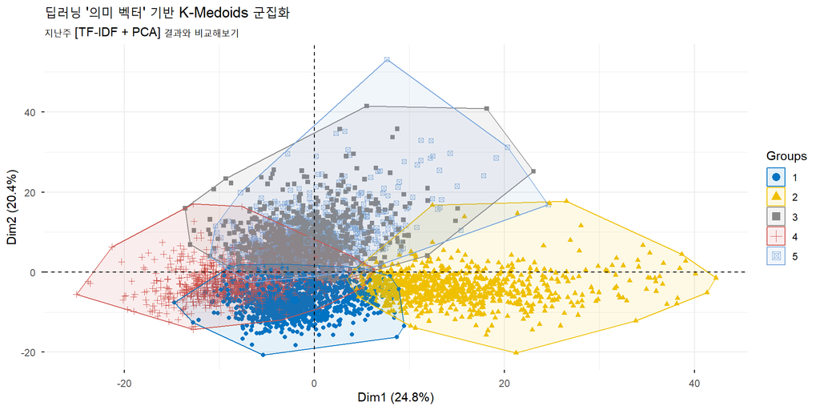

```r
# (3) 지난 수업 복습: K-Medoids 군집화(k = 5)
# (TF-IDF + PCA 벡터 대신, 의미 벡터를 입력)

# [대안] PCA로 50차원 축소 후 K-Medoids 수행(지난 수업 워크플로우와 동일)
# (이유: 200차원 고차원 데이터에서 K-Medoids(`pam()`)는 매우 느릴 수 있음)
# ncp = PCA로 축소할 차원 수. 50차원으로 설정(혹시 모르니 '데이터 수 - 1'보다 작게)
ncp_dim <- min(50, nrow(sentence_vectors) - 1)

# (FactoMineR 패키지의 PCA() 함수) 200차원 -> 50차원 (의미 기반) 축소(graph=FALSE: 그림 안 그림)
pca_for_cluster <- PCA(sentence_vectors, ncp = ncp_dim, graph = FALSE)

# 50차원 축소 결과(벡터)를 추출
pca_vectors_50d <- pca_for_cluster$ind$coord

# cluster 패키지의 pam() 함수) 50차원 의미 벡터를 5개 그룹으로 군집화
set.seed(123) # 재현성을 위해 고정
kmed_result <- pam(pca_vectors_50d, k = 5) # k=5(주제 5개)

# (4) 군집화 결과 vs. 실제 라벨 비교(confusion matrix)
# (라벨이 없는 상황을 가정했지만, 우리는 정답을 알고 있으므로 비교 가능)
m_finetune_ft <- table(True_Label = deeplearning.dataset_tokenized$label_factor, Cluster_ID = kmed_result$clustering)

# (5) [지난 수업 복습] factoextra 패키지를 이용한 시각화
# (시각화를 위한 PCA는 2D만 필요하므로 새로 계산)
pca_for_viz <- PCA(sentence_vectors, ncp = 2, graph = FALSE)

# (6) 시각화 1: K-Medoids 군집 결과
# fviz_cluster()는 K-Medoids(pam()) 객체와 원본 데이터를 함께 받아 PCA 2D로 자동 축소하여 군집을 그려줌
graph_k_medoids <- fviz_pca_ind(pca_for_viz, # 차원축소 결과
                                habillage = as.factor(kmed_result$clustering), # '실제 라벨' 대신 'K-Medoids 군집 결과'로 색칠
                                geom.ind = "point", # 점으로 시각화
                                addEllipses = TRUE,
                                ellipse.type = "convex", # 볼록 껍질(convex hull) 모양
                                palette = "jco", # "Journal of Clinical Oncology" 색상 팔레트
                                ggtheme = theme_minimal()) + # ggplot2 미니멀 테마 적용
  labs( # 그래프 제목 설정
    title = "딥러닝 '의미 벡터' 기반 K-Medoids 군집화",
    subtitle = "지난주 [TF-IDF + PCA] 결과와 비교해보기"
  )
graph_k_medoids # 그래프 출력
```

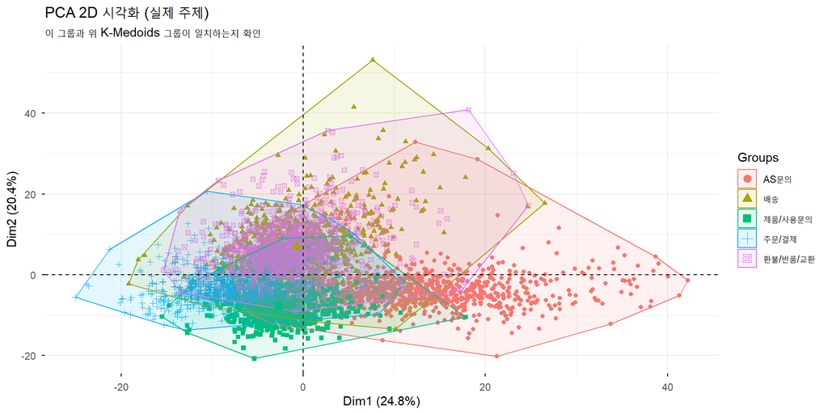

```r
# (7) 시각화 2: 실제 라벨과 비교
# (PCA 2D 축소 결과를 이용해 ggplot처럼 수동 시각화)
graph_pca_true_label <- fviz_pca_ind(pca_for_viz, # 2D PCA 결과
                                     geom.ind = "point", # 점으로 표시
                                     habillage = deeplearning.dataset_tokenized$label_factor, # habillage: PCA 좌표에 '실제 라벨'로 색상 지정
                                     addEllipses = TRUE,
                                     ellipse.type = "convex", # 타원 추가
                                     ggtheme = theme_minimal()) +
  labs(title = "PCA 2D 시각화 (실제 주제)",
       subtitle = "이 그룹과 위 K-Medoids 그룹이 일치하는지 확인")
graph_pca_true_label # 그래프 출력
```